# Project 2

Waheeb Algabri, William Berritt, Kossi Akplaka

2024-07-12

# Loading libraries

```r
library(caret)
library(readxl)
library(dplyr)
library(car)
library(xgboost)
library(e1071)
library(mice)
library(fastDummies)
library(reshape2)
library(openxlsx)
```

# Project Summary

You are given a simple data set from a beverage manufacturing company. It consists of 2,571 rows/cases of data and 33 columns / variables. Your goal is to use this data to predict PH (a column in the set). Potential for hydrogen (pH) is a measure of acidity/alkalinity, it must conform in a critical range and therefore it is important to understand its influence and predict its values. This is production data. pH is a KPI, Key Performance Indicator.

The objective of this project is to predict the pH value using the data provided

# Data loading and exploration

We’ve uploaded the data into GitHub for reproducibility

```r
# Load the dataset
StudentData<- read.csv(
  "https://raw.githubusercontent.com/waheeb123/Data-624/main/Projects/Project-2/StudentData%20-%20TO%20MODEL.csv")

head(StudentData)
```

```
##   Brand.Code Carb.Volume Fill.Ounces PC.Volume Carb.Pressure Carb.Temp   PSC
## 1          B    5.340000    23.96667 0.2633333          68.2     141.2 0.104
## 2          A    5.426667    24.00667 0.2386667          68.4     139.6 0.124
## 3          B    5.286667    24.06000 0.2633333          70.8     144.8 0.090
## 4          A    5.440000    24.00667 0.2933333          63.0     132.6    NA
## 5          A    5.486667    24.31333 0.1113333          67.2     136.8 0.026
## 6          A    5.380000    23.92667 0.2693333          66.6     138.4 0.090
##   PSC.Fill PSC.CO2 Mnf.Flow Carb.Pressure1 Fill.Pressure Hyd.Pressure1
## 1     0.26    0.04     -100          118.8          46.0             0
## 2     0.22    0.04     -100          121.6          46.0             0
## 3     0.34    0.16     -100          120.2          46.0             0
## 4     0.42    0.04     -100          115.2          46.4             0
## 5     0.16    0.12     -100          118.4          45.8             0
## 6     0.24    0.04     -100          119.6          45.6             0
##   Hyd.Pressure2 Hyd.Pressure3 Hyd.Pressure4 Filler.Level Filler.Speed
```

[output cut: 27 more lines]

The training dataset has 33 columns including a categorical variable Brand Code and other predictors of the pH value.

# Data exploration and cleaning

- Average PH in the beverage

Let’s calculate the average PH in the dataset

```r
# Calculate mean of 'PH' column, handling NA values
mean_PH <- mean(StudentData$PH, na.rm = TRUE)

# Print the mean pH
print(paste("The mean pH after handling NA values is:", mean_PH))
```

```
## [1] "The mean pH after handling NA values is: 8.54564861706272"
```

The average pH of an beverage is 8.54. Water naturally varies between about 6.5 and 8.5 on the pH scale. Bottled waters labeled as alkaline can be 8 and 9.

- Different brands of beverage

Categories in Brand Code and Average pH

```r
# Convert 'Brand Code' to factor (categorical)
StudentData_clean$Brand.Code <- as.factor(StudentData_clean$Brand.Code)
```

[output not shown]

```r
# Calculate average pH for each category in 'Brand Code'
brand_pH_avg <- StudentData_clean %>%
  group_by(`Brand.Code`) %>%
  summarise(avg_pH = mean(PH, na.rm = TRUE))
```

[output not shown]

```r
brand_pH_avg
```

[output not shown]

- Summary of the data

```r
summary(StudentData)
```

```
##   Brand.Code         Carb.Volume     Fill.Ounces      PC.Volume
##  Length:2571        Min.   :5.040   Min.   :23.63   Min.   :0.07933
##  Class :character   1st Qu.:5.293   1st Qu.:23.92   1st Qu.:0.23917
##  Mode  :character   Median :5.347   Median :23.97   Median :0.27133
##                     Mean   :5.370   Mean   :23.97   Mean   :0.27712
##                     3rd Qu.:5.453   3rd Qu.:24.03   3rd Qu.:0.31200
##                     Max.   :5.700   Max.   :24.32   Max.   :0.47800
##                     NA's   :10      NA's   :38      NA's   :39
##  Carb.Pressure     Carb.Temp          PSC             PSC.Fill
##  Min.   :57.00   Min.   :128.6   Min.   :0.00200   Min.   :0.0000
##  1st Qu.:65.60   1st Qu.:138.4   1st Qu.:0.04800   1st Qu.:0.1000
##  Median :68.20   Median :140.8   Median :0.07600   Median :0.1800
##  Mean   :68.19   Mean   :141.1   Mean   :0.08457   Mean   :0.1954
##  3rd Qu.:70.60   3rd Qu.:143.8   3rd Qu.:0.11200   3rd Qu.:0.2600
##  Max.   :79.40   Max.   :154.0   Max.   :0.27000   Max.   :0.6200
##  NA's   :27      NA's   :26      NA's   :33        NA's   :23
##     PSC.CO2           Mnf.Flow       Carb.Pressure1  Fill.Pressure
##  Min.   :0.00000   Min.   :-100.20   Min.   :105.6   Min.   :34.60
##  1st Qu.:0.02000   1st Qu.:-100.00   1st Qu.:119.0   1st Qu.:46.00
##  Median :0.04000   Median :  65.20   Median :123.2   Median :46.40
##  Mean   :0.05641   Mean   :  24.57   Mean   :122.6   Mean   :47.92
##  3rd Qu.:0.08000   3rd Qu.: 140.80   3rd Qu.:125.4   3rd Qu.:50.00
##  Max.   :0.24000   Max.   : 229.40   Max.   :140.2   Max.   :60.40
##  NA's   :39        NA's   :2         NA's   :32      NA's   :22
##  Hyd.Pressure1   Hyd.Pressure2   Hyd.Pressure3   Hyd.Pressure4
##  Min.   :-0.80   Min.   : 0.00   Min.   :-1.20   Min.   : 52.00
##  1st Qu.: 0.00   1st Qu.: 0.00   1st Qu.: 0.00   1st Qu.: 86.00
##  Median :11.40   Median :28.60   Median :27.60   Median : 96.00
##  Mean   :12.44   Mean   :20.96   Mean   :20.46   Mean   : 96.29
##  3rd Qu.:20.20   3rd Qu.:34.60   3rd Qu.:33.40   3rd Qu.:102.00
##  Max.   :58.00   Max.   :59.40   Max.   :50.00   Max.   :142.00
##  NA's   :11      NA's   :15      NA's   :15      NA's   :30
##   Filler.Level    Filler.Speed   Temperature      Usage.cont      Carb.Flow
##  Min.   : 55.8   Min.   : 998   Min.   :63.60   Min.   :12.08   Min.   :  26
##  1st Qu.: 98.3   1st Qu.:3888   1st Qu.:65.20   1st Qu.:18.36   1st Qu.:1144
##  Median :118.4   Median :3982   Median :65.60   Median :21.79   Median :3028
##  Mean   :109.3   Mean   :3687   Mean   :65.97   Mean   :20.99   Mean   :2468
##  3rd Qu.:120.0   3rd Qu.:3998   3rd Qu.:66.40   3rd Qu.:23.75   3rd Qu.:3186
##  Max.   :161.2   Max.   :4030   Max.   :76.20   Max.   :25.90   Max.   :5104
##  NA's   :20      NA's   :57     NA's   :14      NA's   :5       NA's   :2
```

[output cut: 9 more lines]

```
##  Min.   :7.880   Min.   :0.00240   Min.   : 70.0   Min.   :44.00
##  1st Qu.:8.440   1st Qu.:0.02200   1st Qu.:100.0   1st Qu.:46.00
##  Median :8.540   Median :0.03340   Median :120.0   Median :46.00
##  Mean   :8.546   Mean   :0.04684   Mean   :109.3   Mean   :47.62
##  3rd Qu.:8.680   3rd Qu.:0.06000   3rd Qu.:120.0   3rd Qu.:50.00
##  Max.   :9.360   Max.   :0.40000   Max.   :140.0   Max.   :52.00
##  NA's   :4       NA's   :12        NA's   :2       NA's   :12
##  Air.Pressurer      Alch.Rel        Carb.Rel      Balling.Lvl
##  Min.   :140.8   Min.   :5.280   Min.   :4.960   Min.   :0.00
##  1st Qu.:142.2   1st Qu.:6.540   1st Qu.:5.340   1st Qu.:1.38
##  Median :142.6   Median :6.560   Median :5.400   Median :1.48
##  Mean   :142.8   Mean   :6.897   Mean   :5.437   Mean   :2.05
##  3rd Qu.:143.0   3rd Qu.:7.240   3rd Qu.:5.540   3rd Qu.:3.14
##  Max.   :148.2   Max.   :8.620   Max.   :6.060   Max.   :3.66
##                  NA's   :9       NA's   :10      NA's   :1
```

[output not shown]

- Missing values

```r
colSums(is.na(StudentData))
```

```
##        Brand.Code       Carb.Volume       Fill.Ounces         PC.Volume
##                 0                10                38                39
##     Carb.Pressure         Carb.Temp               PSC          PSC.Fill
##                27                26                33                23
##           PSC.CO2          Mnf.Flow    Carb.Pressure1     Fill.Pressure
##                39                 2                32                22
##     Hyd.Pressure1     Hyd.Pressure2     Hyd.Pressure3     Hyd.Pressure4
##                11                15                15                30
##      Filler.Level      Filler.Speed       Temperature        Usage.cont
##                20                57                14                 5
##         Carb.Flow           Density               MFR           Balling
##                 2                 1               212                 1
##   Pressure.Vacuum                PH     Oxygen.Filler     Bowl.Setpoint
##                 0                 4                12                 2
## Pressure.Setpoint     Air.Pressurer          Alch.Rel          Carb.Rel
##                12                 0                 9                10
##       Balling.Lvl
##                 1
```

# Data Cleaning

# Feature engineering

After dealing with the missing values in the dataset, we will create dummies varibles for the categorical variable. This enhance the interpretability of the model results. Each dummy variable represents a specific category, making it easier to understand the impact of different categories on the prediction outcome.

- Create dummy variables for ‘Brand Code’

```r
# Create dummies variables
StudentData_clean2 <- fastDummies::dummy_cols(StudentData_clean,
                                              remove_first_dummy = TRUE)

# Remove the Brand Code column
StudentData_clean2 <- subset(StudentData_clean2, select = - Brand.Code)

# Print the 5 elements of the data
head(StudentData_clean2)
```

```
##   Carb.Volume Fill.Ounces PC.Volume Carb.Pressure Carb.Temp   PSC PSC.Fill
## 1    5.340000    23.96667 0.2633333          68.2     141.2 0.104     0.26
## 2    5.426667    24.00667 0.2386667          68.4     139.6 0.124     0.22
## 3    5.286667    24.06000 0.2633333          70.8     144.8 0.090     0.34
## 4    5.440000    24.00667 0.2933333          63.0     132.6 0.078     0.42
## 5    5.486667    24.31333 0.1113333          67.2     136.8 0.026     0.16
## 6    5.380000    23.92667 0.2693333          66.6     138.4 0.090     0.24
##   PSC.CO2 Mnf.Flow Carb.Pressure1 Fill.Pressure Hyd.Pressure1 Hyd.Pressure2
## 1    0.04     -100          118.8          46.0             0           0.2
## 2    0.04     -100          121.6          46.0             0           0.0
## 3    0.16     -100          120.2          46.0             0           0.2
## 4    0.04     -100          115.2          46.4             0           0.0
## 5    0.12     -100          118.4          45.8             0           0.0
## 6    0.04     -100          119.6          45.6             0           0.0
##   Hyd.Pressure3 Hyd.Pressure4 Filler.Level Filler.Speed Temperature Usage.cont
```

[output cut: 27 more lines]

# Outlier Detection and Removal

- Remove outliers in the data

We defined a function remove_outliers_specific to remove outliers based on the interquartile range Q3 and Q1 for the PH column.

```r
# Function to remove rows containing outliers based on IQR for a specific column
remove_outliers_specific <- function(df, column_name) {
  # Copy the dataframe to avoid modifying the original
  df_clean <- df

  # Calculate quartiles and IQR for the specified column
  Q1 <- quantile(df[[column_name]], 0.25)
  Q3 <- quantile(df[[column_name]], 0.75)
  IQR_val <- Q3 - Q1

  # Define the lower and upper bounds for outliers
  lower_bound <- Q1 - 1.5 * IQR_val
  upper_bound <- Q3 + 1.5 * IQR_val

  # Identify rows with outliers in the specified column
  outliers <- df[[column_name]] < lower_bound | df[[column_name]] > upper_bound

  # Subset the dataframe to keep only rows without outliers for the specified column
  df_clean <- df[!outliers, ]

  return(df_clean)
}

# Remove outliers specifically from the PH column
StudentData_clean3 <- remove_outliers_specific(StudentData_clean2, "PH")
```

# Data Exploration

First, we will compute the correlation and visualize the correlation matrix

- Correlation and visualization

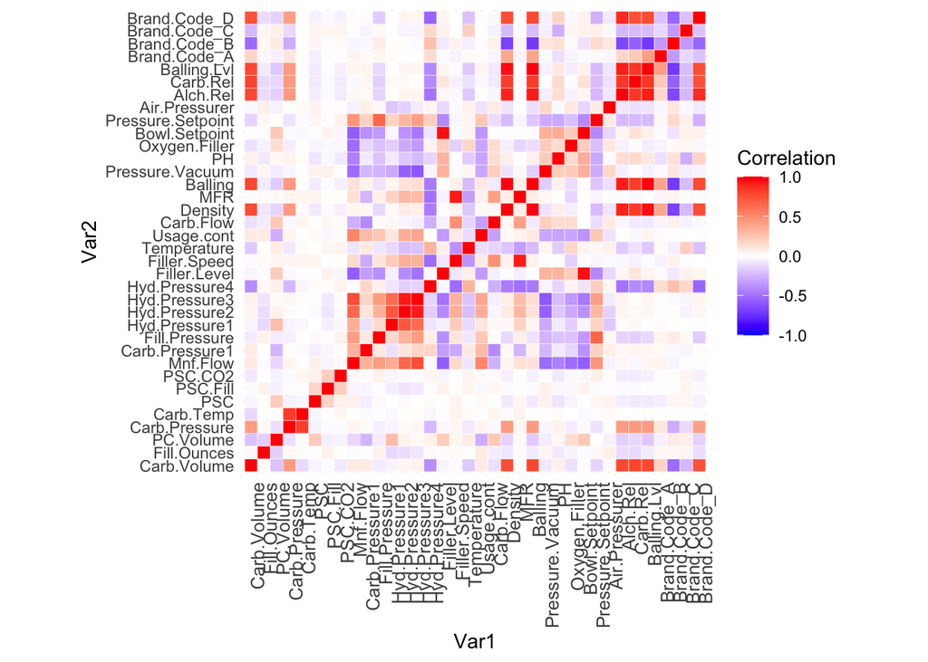

```r
# Calculate the correlation matrix
correlation_matrix <- cor(StudentData_clean3)

# Convert the correlation matrix to long format for plotting
cor_melted <- melt(correlation_matrix)

# Plot the heatmap
ggplot(cor_melted, aes(Var1, Var2, fill = value)) +
  geom_tile(color = "white") +
  scale_fill_gradient2(low = "blue", high = "red", mid = "white", midpoint = 0,
                       limit = c(-1, 1), space = "Lab", name="Correlation") +
  theme_minimal() +
  theme(axis.text.x = element_text(angle = 90, vjust = 1, size = 10, hjust = 1)) +
  coord_fixed()
```

There are high collinearities between the variables Carb Pressure, Hyd Pressure3, Balling Lvl, and Carb Rel.

```r
StudentData_clean3 <- StudentData_clean3[, !colnames(StudentData_clean3) %in% "Carb Pressure"]
StudentData_clean3 <- StudentData_clean3[, !colnames(StudentData_clean3) %in% "Hyd Pressure3"]
StudentData_clean3 <- StudentData_clean3[, !colnames(StudentData_clean3) %in% "Balling Lvl"]
StudentData_clean3 <- StudentData_clean3[, !colnames(StudentData_clean3) %in% "Carb Rel"]
```

# Model Building

We split the data 80% to 20% between training and testing set

```r
set.seed(123)  # for reproducibility
trainIndex <- createDataPartition(StudentData_clean3$PH, p = 0.8, list = FALSE)
trainData <- StudentData_clean3[trainIndex, ]
testData <- StudentData_clean3[-trainIndex, ]
```

- Linear regression model

Linear models provide straightforward interpretation of coefficients. Each predictor’s coefficient indicates the strength and direction of its relationship with the dependent variable. This makes it easy to understand the impact of each predictor on the outcome.

```r
set.seed(123)
# Linear Regression
model_lm <- lm(PH ~ ., data = trainData)
predictions_lm <- predict(model_lm, newdata = testData)
rsq_lm <- cor(predictions_lm, testData$PH)^2
```

- Support Vector Regression model

Support Vector Machines (SVMs) are another powerful technique for predicting beverage pH based on other variables. SVMs are effective in scenarios where the relationship between predictors and the outcome (pH) is not necessarily linear and can exhibit complex patterns. SVMs work by finding the optimal hyperplane to predict continuous outcomes. SVMs can handle datasets with a small number of samples

```r
set.seed(123)
# Support Vector Regression (SVR)
model_svr <- svm(PH ~ ., data = trainData)
predictions_svr <- predict(model_svr, newdata = testData)
rsq_svr <- cor(predictions_svr, testData$PH)^2
```

- Interpret the result

Print R-squared values for comparison

```r
cat("Linear Regression R-squared:", rsq_lm, "\n")
```

```
## Linear Regression R-squared: 0.3939437
```

```r
cat("XGBoost R-squared:", rsq_xgb, "\n")
```

```
## XGBoost R-squared: 0.6661361
```

```r
cat("Support Vector Regression R-squared:", rsq_svr, "\n")
```

```
## Support Vector Regression R-squared: 0.5748125
```

R-squared values highlight the superior predictive performance of XGBoost over linear regression and SVR in modeling beverage pH based on other variables, emphasizing its ability to handle complex relationships and improve model accuracy.

- Most important predictors of pH using XGBoost

```r
# Extract feature importance
importance_scores <- xgb.importance(model = model_xgb)

# Print the top 5
head(importance_scores, 5)
```

```
##          Feature       Gain       Cover   Frequency
## 1:      Mnf.Flow 0.16240814 0.032651413 0.030383091
## 2: Oxygen.Filler 0.06624467 0.058054595 0.046235139
## 3: Bowl.Setpoint 0.05884868 0.007818238 0.004755614
## 4:  Brand.Code_C 0.05328164 0.007980973 0.003434610
## 5:      Alch.Rel 0.04961529 0.038023406 0.025627477
```

- Comparing actual vs. predicted values

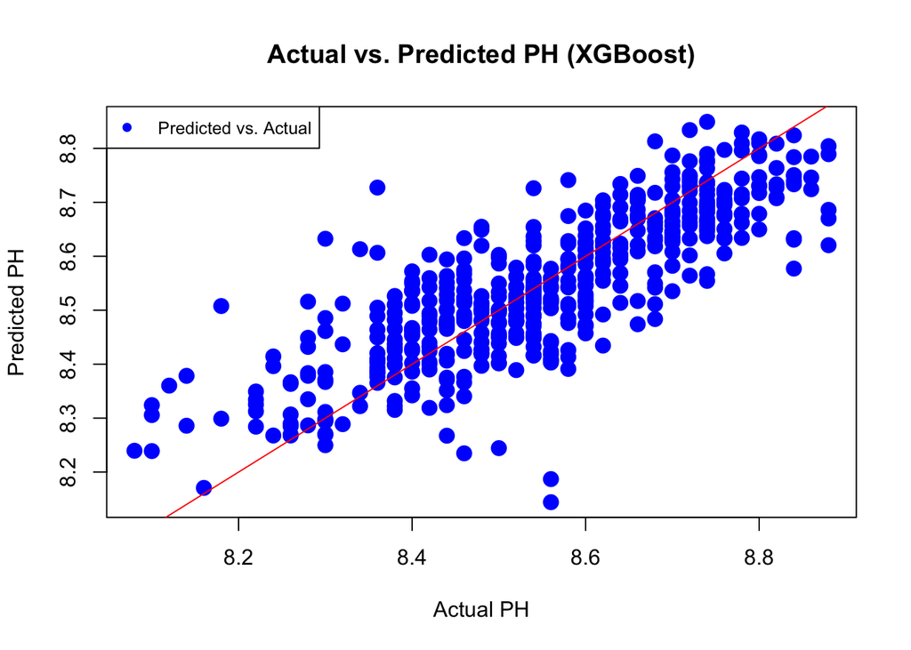

```r
plot(testData$PH, predictions_xgb,
     main = "Actual vs. Predicted PH (XGBoost)",
     xlab = "Actual PH",
     ylab = "Predicted PH",
     col = "blue",
     pch = 19,
     cex = 1.5)

# Add a diagonal line to show perfect predictions
abline(0, 1, col = "red")

# Add legend
legend("topleft", legend = "Predicted vs. Actual", col = c("blue", "red"), pch = c(19, NA), lty = c(NA, 1), cex = 0.8)
```

# Scoring using the best prediction

Load the data

```r
# Load necessary libraries
library(readxl)  # For reading Excel files

# Read new data from Excel file
data <- read.csv("https://raw.githubusercontent.com/waheeb123/Data-624/main/Projects/Project-2/StudentEvaluation-%20TO%20PREDICT.csv")
```

Replace null values in Brand Code with the most common brand

```r
brand_counts <- table(data$Brand.Code)
most_common_brand <- names(which.max(brand_counts))
data$Brand.Code[is.na(data$Brand.Code)] <- most_common_brand
```

```r
submission_df <- submission_df[, !colnames(submission_df) %in% "Carb Pressure"]
submission_df <- submission_df[, !colnames(submission_df) %in% "Hyd Pressure3"]
submission_df <- submission_df[, !colnames(submission_df) %in% "Balling Lvl"]
submission_df <- submission_df[, !colnames(submission_df) %in% "Carb Rel"]
```

Create dummy variables

```r
# Create dummies variables
submission_df <- fastDummies::dummy_cols(submission_df,
                                              remove_first_dummy = TRUE)

# Remove the Brand Code column
submission_df <- subset(submission_df, select = - Brand.Code)

# Print the 5 elements of the data
head(submission_df)
```

```
##   Carb.Volume Fill.Ounces PC.Volume Carb.Pressure Carb.Temp   PSC PSC.Fill
## 1    5.480000    24.03333 0.2700000          65.4     134.6 0.236     0.40
## 2    5.393333    23.95333 0.2266667          63.2     135.0 0.042     0.22
## 3    5.293333    23.92000 0.3033333          66.4     140.4 0.068     0.10
## 4    5.266667    23.94000 0.1860000          64.8     139.0 0.004     0.20
## 5    5.406667    24.20000 0.1600000          69.4     142.2 0.040     0.30
## 6    5.286667    24.10667 0.2120000          73.4     147.2 0.078     0.22
##   PSC.CO2 Mnf.Flow Carb.Pressure1 Fill.Pressure Hyd.Pressure1 Hyd.Pressure2
## 1    0.04     -100          116.6          46.0             0             0
## 2    0.08     -100          118.8          46.2             0             0
## 3    0.02     -100          120.2          45.8             0             0
## 4    0.02     -100          124.8          40.0             0             0
## 5    0.06     -100          115.0          51.4             0             0
## 6    0.02     -100          118.6          46.4             0             0
##   Hyd.Pressure3 Hyd.Pressure4 Filler.Level Filler.Speed Temperature Usage.cont
```

[output cut: 27 more lines]

Predict the PH using the XGBoost model

```r
# Convert df_test to xgb.DMatrix format
submission_df_xgb <- xgb.DMatrix(as.matrix(
  submission_df[, -which(names(submission_df) == "PH")]))

# Predict using the XGBoost model
predictions_xgb <- predict(model_xgb, submission_df_xgb)

# Replace PH column in df_test with predictions
submission_df$PH <- predictions_xgb
```

Export the data

```r
data$PH <- submission_df$PH

# Define file path for the Excel file
file_path <- "submission_df_proj_2_624.xlsx"

# Export submission_df to Excel
write.xlsx(data, file_path, rowNames = FALSE)
```